# Analisis Correspondencias Canonicas

franmarq@gmail.com

2022-11-12

Lectura del conjunto de datos

```r
data<-read.csv("BaseMedidasECOBebe3.csv",header=T,sep = ',')
names(data)
```

```
## [1] "id"            "Sexo_RN"       "DBP_34"        "PC_34"
## [5] "PA_34"         "PESO_RN"       "TALLA_RN"      "P_Cefalico_RN"
## [9] "P_Toracico_RN"
```

```r
X <- data[, 3:5]
Y <- data[,6:9]
X
```

```
##     DBP_34  PC_34  PA_34
## 1    88.42 310.06 295.88
## 2    83.14 298.75 299.00
## 3    84.96 289.63 297.16
## 4    79.72 285.57 283.31
## 5    80.90 289.12 271.94
## 6    82.84 311.90 299.87
## 7    86.52 309.74 301.57
## 8    83.67 304.35 292.84
## 9    80.59 296.33 308.11
## 10   80.38 291.46 290.10
## 11   86.63 313.89 292.20
## 12   83.42 298.86 267.44
## 13   85.25 303.74 285.78
## 14   84.32 282.16 306.00
```

[output cut: 369 more lines]

```r
Y
```

```
##     PESO_RN TALLA_RN P_Cefalico_RN P_Toracico_RN
## 1      1140    50.65         33.73         32.91
## 2      1645    40.00         33.73         32.91
## 3      1740    42.00         30.00         32.91
## 4      1790    50.65         33.73         27.00
## 5      1890    44.00         31.00         32.91
## 6      1950    43.00         33.73         26.00
## 7      2160    47.00         32.00         27.00
## 8      2190    46.00         33.73         32.91
## 9      2200    45.00         29.00         27.00
## 10     2210    45.00         30.00         27.00
## 11     2240    48.00         33.73         30.00
## 12     2240    48.00         30.00         29.00
## 13     2410    50.65         31.00         38.00
## 14     2430    47.00         30.00         30.00
```

[output cut: 369 more lines]

La variable Sexo no será incluida porque su naturaleza es binaria. Iniciamos el análisis examinando las correlaciones bivariadas de las variables de ambos conjuntos, independientes (X) y dependientes (Y)

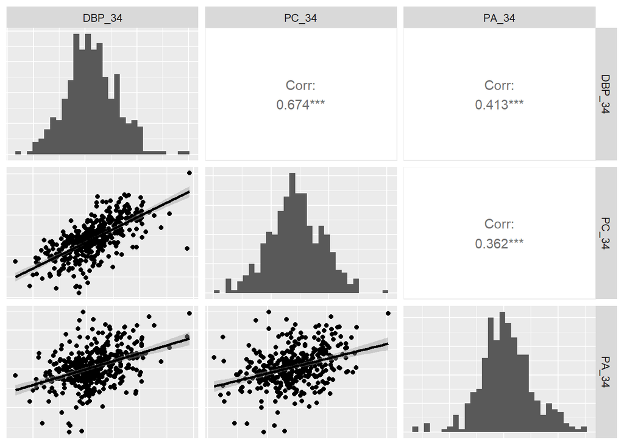

```r
require(GGally)
ggpairs(X, lower = list(continuous = "smooth"),
        diag = list(continuous = "barDiag"), axisLabels = "none")
```

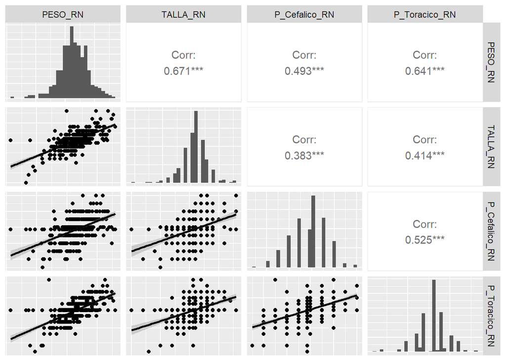

```r
ggpairs(Y, lower = list(continuous = "smooth"),
        diag = list(continuous = "barDiag"), axisLabels = "none")
```

Luego, calculamos la matrix de correlaciones

```r
require(CCA)
matriz.corr<-matcor(X,Y)
matriz.corr
```

```
## $Xcor
##           DBP_34     PC_34     PA_34
## DBP_34 1.0000000 0.6735858 0.4125598
## PC_34  0.6735858 1.0000000 0.3623757
## PA_34  0.4125598 0.3623757 1.0000000
##
## $Ycor
##                 PESO_RN  TALLA_RN P_Cefalico_RN P_Toracico_RN
## PESO_RN       1.0000000 0.6708856     0.4925962     0.6409263
## TALLA_RN      0.6708856 1.0000000     0.3827280     0.4137903
## P_Cefalico_RN 0.4925962 0.3827280     1.0000000     0.5254366
## P_Toracico_RN 0.6409263 0.4137903     0.5254366     1.0000000
##
## $XYcor
##                  DBP_34     PC_34     PA_34   PESO_RN  TALLA_RN P_Cefalico_RN
## DBP_34        1.0000000 0.6735858 0.4125598 0.3146787 0.2021145     0.2481283
## PC_34         0.6735858 1.0000000 0.3623757 0.3469102 0.1923816     0.2910819
## PA_34         0.4125598 0.3623757 1.0000000 0.4376497 0.1997894     0.2883503
## PESO_RN       0.3146787 0.3469102 0.4376497 1.0000000 0.6708856     0.4925962
## TALLA_RN      0.2021145 0.1923816 0.1997894 0.6708856 1.0000000     0.3827280
## P_Cefalico_RN 0.2481283 0.2910819 0.2883503 0.4925962 0.3827280     1.0000000
## P_Toracico_RN 0.2976894 0.2530248 0.3239011 0.6409263 0.4137903     0.5254366
##               P_Toracico_RN
## DBP_34            0.2976894
## PC_34             0.2530248
## PA_34             0.3239011
## PESO_RN           0.6409263
## TALLA_RN          0.4137903
## P_Cefalico_RN     0.5254366
## P_Toracico_RN     1.0000000
```

usamos ahora el grafico de la imagen de la matriz de correlaciones

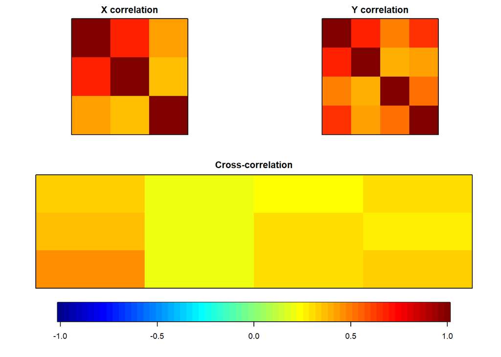

```r
img.matcor(matriz.corr,type=2)
```

Obtenemos ahora las correlaciones canonicas, empezando por la primera variable canonica

```r
cca.datos<-cc(X,Y)
cca.datos$cor[1]
```

```
## [1] 0.5149062
```

ahora bien, usamos la siguiente función para obtener las primeras variables canónicas

```r
print("Coeficientes X")
```

```
## [1] "Coeficientes X"
```

```r
cca.datos$xcoef[,1]
```

```
##      DBP_34       PC_34       PA_34
## -0.02109376 -0.04649637 -0.07454085
```

```r
print("Coeficientes Y")
```

```
## [1] "Coeficientes Y"
```

```r
cca.datos$ycoef[,1]
```

```
##       PESO_RN      TALLA_RN P_Cefalico_RN P_Toracico_RN
##  -0.002020426   0.148252340  -0.193782395  -0.030828507
```

Ahora, obtenemos gráficos adicionales que nos pueden servir de apoyo para el análisis

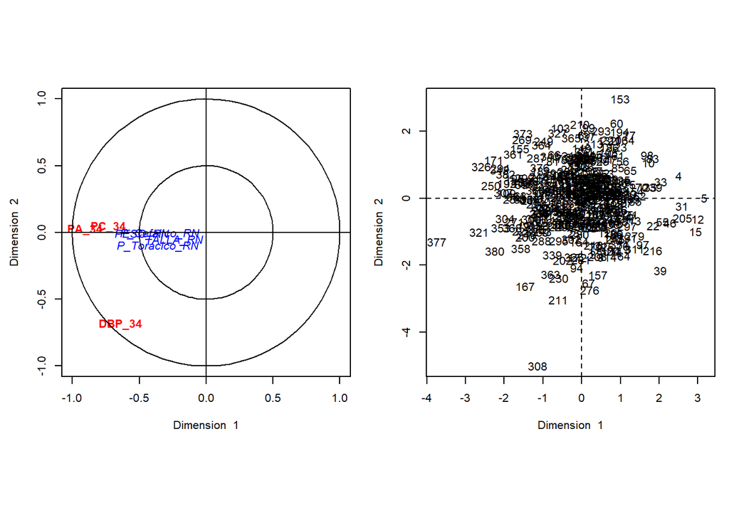

```r
plt.cc(cca.datos,var.label=TRUE)
```

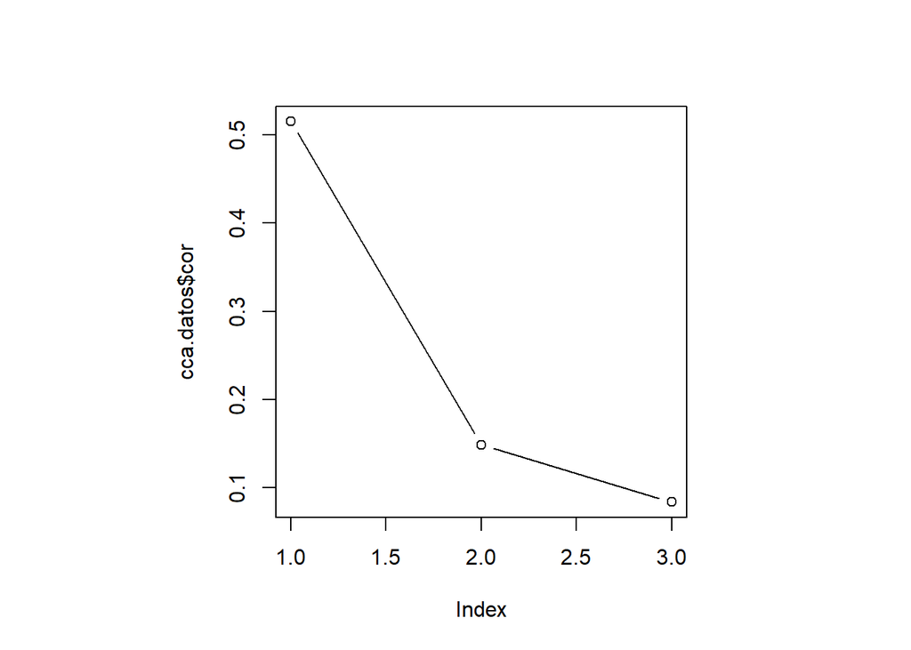

```r
plot(cca.datos$cor,type="b")
```

Ahora vamos a aplicar los test

```r
require(CCP)
rho<- cca.datos$cor
n<- dim(X)[1]
p<-length(X)
q<-length(Y)
p.asym(rho,n,p,q)
```

```
## Wilks' Lambda, using F-approximation (Rao's F):
##               stat    approx df1     df2   p.value
## 1 to 3:  0.7135735 11.281336  12 995.094 0.0000000
## 2 to 3:  0.9710181  1.861596   6 754.000 0.0848270
## 3 to 3:  0.9929494  1.342034   2 378.000 0.2625558
```

Del resultado obtenido, al tener tres variables canonicas se resuelven los siguientes contrastes:

H0:p1=p2=p3=0, el segundo el de H0:p2=p3=0 y por último H0:p3=0, resultando:

tercer contraste: p-valor mayor a 0.05 por lo que no se rechaza HO, esto indica que la tercera variable canonica no sea significativa.